# Formatted Output & R Markdown Presentations

## Creating presentations with R Markdown

## Brief overview of ioslides

### Creating slides from R Markdown

1. To create an **ioslides** presentation from R Markdown, specify *ioslides_presentation* in the YAML header (**beamer** and **slidy** are other R Markdown presentation types)
2. Use # for a new section; and ## for a new slide. Use | for adding a subtitle
3. Can set slides to display smaller text {.smaller} or display the slide content incrementally {.build}, for example:

```r
## Slide title {.smaller .build}
```

[Here](https://garrettgman.github.io/rmarkdown/ioslides_presentation_format.html) is a short tutorial. See Chapter 4.1 in [R Markwdown: The Definitive Guide](https://bookdown.org/yihui/rmarkdown/ioslides-presentation.html) for a more comprehensive treatment.

## Using Stargazer for formatted output

## Loading packages

First load the packages *tidyverse*, *stargazer*, *knitr*, *plm*, *lmtest* and *multiwayvcov*.

**stargazer** is an R package that creates LATEX code, HTML code and ASCII text for displaying:

- formatted regression tables, w/multiple models side-by-side
- tables for summary statistics
- data frames

## Loading data for today’s examples

Load cleaned Village Fund data:

```
## # A tibble: 6 x 5
##   province regency                   vfund_allocation poverty vfund_per_poor
##   <chr>    <chr>                                <dbl>   <dbl>          <dbl>
## 1 Aceh     Kabupaten Aceh Barat               220833.    39.6          5582.
## 2 Aceh     Kabupaten Aceh Barat Daya          105480.    25.2          4181.
## 3 Aceh     Kabupaten Aceh Besar               394139.    60.1          6560.
## 4 Aceh     Kabupaten Aceh Jaya                117811.    12.8          9168.
## 5 Aceh     Kabupaten Aceh Selatan             180347.    32.8          5495.
## 6 Aceh     Kabupaten Aceh Singkil              90964.    25.7          3534.
```

Load cleaned Detroit data (cross-sectional and panel; panel data shown here)

```
## # A tibble: 6 x 11
##    zip5 total_obs si_count viral_infect vac_res total_res pop2015 total_obs_1000
##   <int>     <int>    <dbl>        <int>   <dbl>     <dbl>   <dbl>          <dbl>
## 1 48201     20467       50          269   1511.    17159.   13049          1568.
## 2 48202     19404     1319          228   2882.    12448.   16696          1162.
## 3 48203     36240     2967          475   5470.    22137.   25027          1448.
## 4 48204     34497     5134          381   7200.    22595.   25637          1346.
## 5 48205     46490    12614          612   8294.    26447.   36834          1262.
## 6 48206     25567     3301          348   4249.    11342.   18424          1388.
## # … with 3 more variables: si_1000 <dbl>, viral_infect_1000 <dbl>,
## #   vac_res_p100 <dbl>
```

## Descriptive statistics of numeric variables

We can use stargazer to show summary stats for numeric variables in a data frame.

The R Markdown code chunk options should include `results = 'asis'`, and the `stargazer()` function should include the argument `type = "html"`:

```r
out <- capture.output(stargazer(as.data.frame(vf_joined), type = "html",
          summary.stat = c("n", "mean", "sd", "min", "max"), #specify columns
          covariate.labels = c("VF allocation",
                               "Population in poverty (1000s)",
                               "VF allocation/poor residents"),
          align = TRUE, digits = 2, column.sep.width = "15pt", #other formatting
          notes = "Village Fund amounts in millions of rupiah."))

out <- sub("text-align:center", "text-align:left", out) #a hack to align left

cat(out)
```

| Statistic | N | Mean | St. Dev. | Min | Max |
| --- | --- | --- | --- | --- | --- |
| VF allocation | 434 | 138,248.90 | 86,624.02 | 16,502.69 | 561,531.40 |
| Population in poverty (1000s) | 434 | 52.99 | 57.07 | 1.34 | 415.02 |
| VF allocation/poor residents | 434 | 4,611.66 | 3,954.04 | 547.27 | 32,900.17 |
| Village Fund amounts in millions of rupiah. |  |  |  |  |  |

## Descriptive statistics of numeric variables

[Here](https://www.jakeruss.com/cheatsheets/stargazer) is a good tutorial with more stargazer examples and formatting options.

## Difference-in-means table

In the data, provinces on Java island are *Banten*, *Di Yogyakarta*, and those starting with *Jawa*; provinces on Sulawesi island are *Gorontalo* and those starting with *Sulawesi*.

[Here](https://sebastiansauer.github.io/multiple-t-tests-with-dplyr/) is a tutorial for making this kind of table, shown below.

| Variable | Mean (Java) | N (Java) | Mean (Sulawesi) | N (Sulawesi) | p-value |
| --- | --- | --- | --- | --- | --- |
| Population in poverty (1000s) | 137.60 | 86 | 26.25 | 71 | 0.00 |
| VF allocation/poor residents | 1773.33 | 86 | 4603.95 | 71 | 0.00 |

## Regression tables

Columns 1 and 2 show results from the cross-sectional regression outputs without and with vacancy rate as a control variable, respectively.

|  | *Dependent variable:* |  |
| --- | --- | --- |
|  | total_obs_1000 |  |
|  | (1) | (2) |
| si_1000 | 0.904** | 0.568 |
|  | (0.373) | (0.471) |
| vac_res_p100 |  | 8.681** |
|  |  | (4.216) |
| Constant | 1,024.112*** | 921.027*** |
|  | (89.413) | (94.859) |
| Observations | 30 | 29 |
| Adjusted R<sup>2</sup> | 0.146 | 0.206 |
| *Note:* | p<0.1; p<0.05; p<0.01 |  |
|  | Robust SEs shown in parentheses. |  |

## Regression tables

Full regression equation:

\[total\_obs\_1000_{zt} = \beta_0 + \beta_1 si\_1000_{zt} + \beta_2 vac\_res\_p100_{zt} + \phi_z + \theta_t + u_{zt}\]

Columns 1 and 2 show results from the fixed effects regressions we estimated in class without the vacancy rate control, columns 3 and 4 include vacancy rate as a control variable.

|  | *Dependent variable:* |  |  |  |
| --- | --- | --- | --- | --- |
|  | total_obs_1000 |  |  |  |
|  | (1) | (2) | (3) | (4) |
| si_1000 | 0.013** | 0.013* | 0.016*** | 0.016** |
|  | (0.006) | (0.007) | (0.006) | (0.007) |
| vac_res_p100 |  |  | -0.156*** | -0.156*** |
|  |  |  | (0.012) | (0.059) |
| Constant | 17.562*** | 17.562*** | 18.351*** | 18.351*** |
|  | (0.302) | (0.251) | (0.274) | (0.307) |
| Zip code FE | Yes | Yes | Yes | Yes |
| Month FE | Yes | Yes | Yes | Yes |
| Clustered SEs | No | Zipcode | No | Zipcode |
| Mean dep var | 12.43 | 12.43 | 12.43 | 12.43 |
| Observations | 2,880 | 2,880 | 2,784 | 2,784 |
| Adjusted R<sup>2</sup> | 0.835 | 0.835 | 0.846 | 0.846 |
| *Note:* | p<0.1; p<0.05; p<0.01 |  |  |  |
|  | Robust standard errors are shown in parentheses unless otherwise indicated. |  |  |  |

## Creating bullet points

- This is a bullet point
- This is another bullet point
- This is another bullet point

## Add a plot

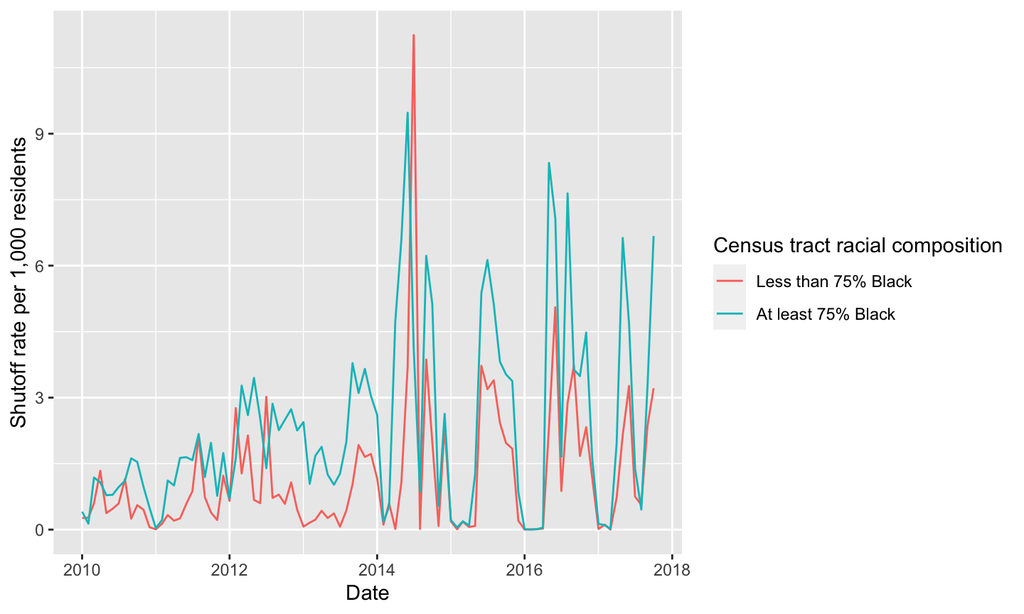